# Temperature anomalies and bluetongue outbreaks in Europe

Author

Ali ABADA, DVM

Published

November 17, 2026

```r
library(tidyverse)
library(sf)
library(rnaturalearth)
library(glmmTMB)
library(broom.mixed)
library(here)

panel  <- read_csv(here("data", "processed", "bt_climate_panel.csv"), show_col_types = FALSE)
models <- readRDS(here("output", "models.rds"))
```

## Question

Are warmer-than-usual years associated with more bluetongue outbreaks in European countries? Bluetongue is a vector-borne disease of ruminants transmitted by *Culicoides* midges, whose activity and range are expected to respond to temperature.

## Data

- **Outbreaks:** official bluetongue outbreak notifications from the EU Animal Disease Information System (ADIS), aggregated by country and year. Country-years with no notified outbreak are set to zero.
- **Climate:** annual temperature anomalies per country relative to 1991–2020, from Our World in Data, derived from the Copernicus ERA5 reanalysis.

```r
panel |>
  summarise(countries = n_distinct(iso3),
            years = paste(min(year), max(year), sep = "–"),
            total_outbreaks = sum(outbreaks),
            share_zero = scales::percent(mean(outbreaks == 0)))
```

```
# A tibble: 1 × 4
  countries years     total_outbreaks share_zero
      <int> <chr>               <dbl> <chr>
1        31 2005–2025          137537 69%
```

## Outbreaks over time

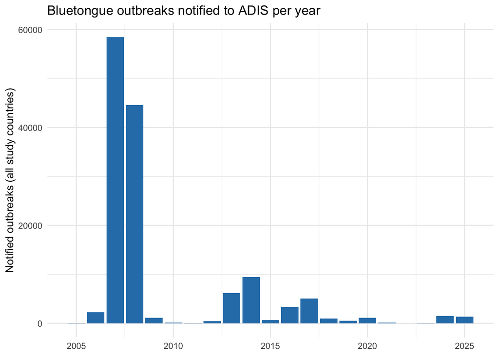

```r
panel |>
  group_by(year) |>
  summarise(outbreaks = sum(outbreaks), temp_anomaly = mean(temp_anomaly, na.rm = TRUE)) |>
  ggplot(aes(year, outbreaks)) +
  geom_col(fill = "#2c7fb8") +
  labs(x = NULL, y = "Notified outbreaks (all study countries)",
       title = "Bluetongue outbreaks notified to ADIS per year") +
  theme_minimal()
```

## Where outbreaks were reported

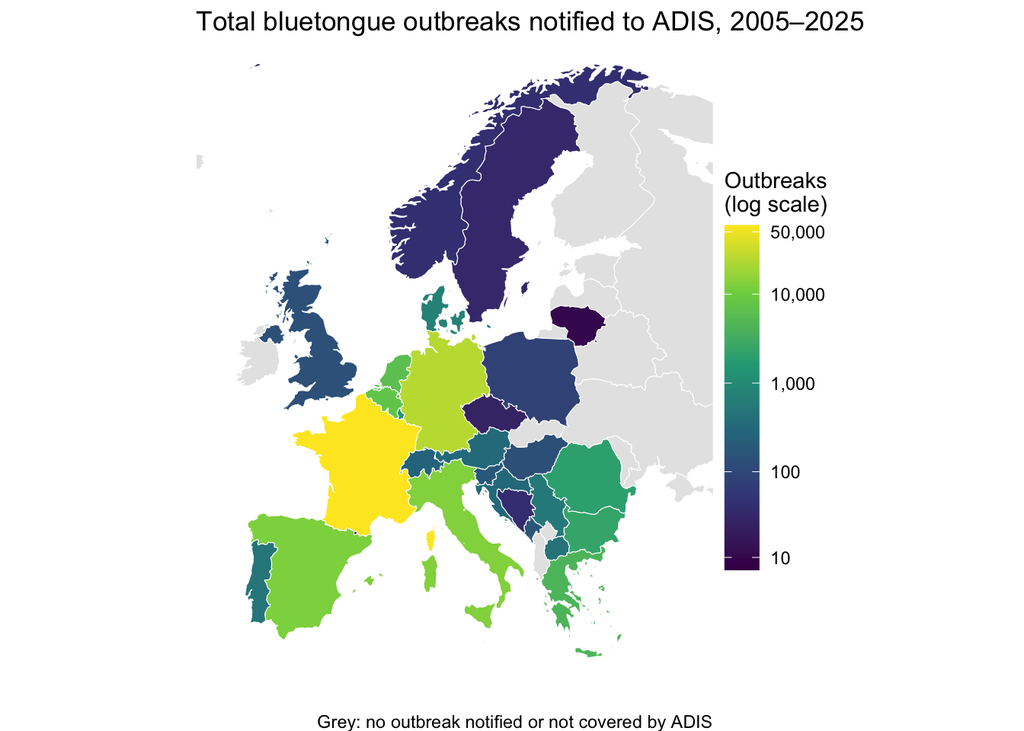

```r
europe <- ne_countries(scale = "medium", continent = "Europe", returnclass = "sf") |>
  dplyr::select(iso3 = iso_a3_eh, geometry)

totals <- panel |> group_by(iso3) |> summarise(outbreaks = sum(outbreaks))

europe |>
  left_join(totals, by = "iso3") |>
  ggplot() +
  geom_sf(aes(fill = outbreaks), colour = "white", linewidth = 0.2) +
  scale_fill_viridis_c(trans = "log1p", na.value = "grey90",
                       breaks = c(0, 10, 100, 1000, 10000, 50000),
                       labels = scales::label_comma(),
                       name = "Outbreaks\n(log scale)") +
  coord_sf(xlim = c(-12, 35), ylim = c(34, 71)) +
  labs(title = "Total bluetongue outbreaks notified to ADIS, 2005–2025",
       caption = "Grey: no outbreak notified or not covered by ADIS") +
  theme_void() +
  theme(legend.key.height = unit(1.2, "cm"))
```

## Model

The country random intercept absorbs stable differences between countries, such as livestock population, surveillance intensity and reporting practice. The year trend captures changes over time that are not linked to temperature, such as vaccination campaigns.

```r
AIC(models$pois, models$nb, models$nbmm)
```

```
            df        AIC
models$pois  4 875591.065
models$nb    5   2957.943
models$nbmm  6   2909.680
```

```r
tidy(models$nbmm, effects = "fixed", conf.int = TRUE, exponentiate = TRUE) |>
  dplyr::select(term, IRR = estimate, conf.low, conf.high, p.value) |>
  mutate(across(where(is.numeric), \(x) round(x, 3)))
```

```
# A tibble: 4 × 5
  term           IRR conf.low conf.high p.value
  <chr>        <dbl>    <dbl>     <dbl>   <dbl>
1 (Intercept)  5.90     1.81     19.3     0.003
2 temp_anomaly 9.47     2.89     31.0     0
3 year_c       0.807    0.698     0.934   0.004
4 ahl_period   4.45     0.707    28.0     0.112
```

The incidence rate ratio (IRR) for `temp_anomaly` is the multiplicative change in expected outbreaks for a +1 °C annual anomaly, holding country and trend constant.

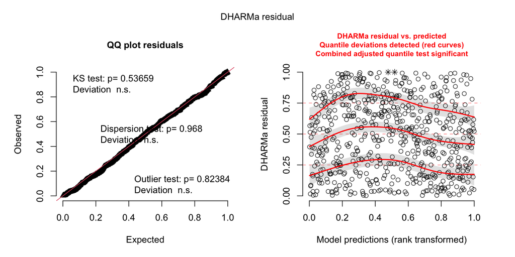

Residual diagnostics (DHARMa)

## Sensitivity analyses

```r
read_csv(here("output", "sensitivity_irr.csv"), show_col_types = FALSE)
```

```
# A tibble: 5 × 6
  model                                          n   IRR ci_low ci_high        p
  <chr>                                      <dbl> <dbl>  <dbl>   <dbl>    <dbl>
1 1. Main model (2005-2025)                    630  9.47   2.89   31.0  2.1 e- 4
2 2. Excluding BTV-8 epidemic (2006-2008)      540  3.34   1.11   10.1  3.2 e- 2
3 3. Before Animal Health Law (2005-2020)      480 16.3    3.97   66.7  1.1 e- 4
4 4. Year random effect (Europe-wide shocks)   630  1.88   0.67    5.25 2.3 e- 1
5 5. Previous year's anomaly (lag 1)           600 43.6   15.9   119.   2.20e-13
```

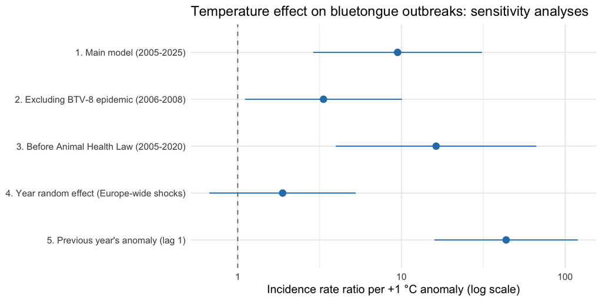

Temperature effect across models (IRR per +1 °C, 95% CI, log scale)

## Results

Bluetongue outbreak counts were strongly over-dispersed (Poisson dispersion ratio ≈ 8,300), and the negative-binomial mixed model with a country random intercept fitted best (AIC 2,910 vs 2,958 without it and 875,591 for Poisson).

In the main model, a +1 °C annual temperature anomaly was associated with about nine times more notified outbreaks (IRR 9.5, 95% CI 2.9–31). This estimate is not robust. Excluding the 2006–2008 BTV-8 epidemic reduced it to 3.3 (1.1–10.1). Adding a year random effect, which absorbs Europe-wide shocks such as epidemic waves and vaccination campaigns, reduced it to 1.9 (0.7–5.3), no longer distinguishable from no effect. The very large lagged estimate (IRR 43.6) mainly reflects the warm 2006 being followed by the 2007 BTV-8 wave.

Warmer years are therefore associated with more bluetongue outbreaks, but at country-year resolution this association cannot be separated from epidemic waves and serotype incursions. When countries are compared within the same year, the effect remains positive but uncertain.

## Limitations

- **Reporting bias.** Notified outbreaks reflect surveillance and reporting effort as well as disease. The country random effect only handles differences that are stable over time.
- **Vaccination and serotypes.** Large vaccination campaigns and new serotype incursions (for example BTV-8 in 2006–2008 and BTV-3 from 2023) drive outbreaks strongly and are not modelled here.
- **Coarse climate data.** A national annual anomaly hides seasonal and local conditions that matter for *Culicoides*; monthly, sub-national data would be more appropriate.
- **Association, not causation.** This is an ecological analysis at country-year level.

## Next steps

Monthly and sub-national ERA5 data, vector habitat covariates, serotype and vaccination information, and spatio-temporal models (for example INLA) would make the analysis much stronger. WAHIS data would extend it beyond the EU.